# Module 73

#### Hemi-module gene counts:

471 probesets in hemi-module A.  
114 probesets in hemi-module B.  
Note: While the mapping of probesets to genes is usually one-to-one, some genes are targeted by multiple probesets, some probesets target multiple genes, and some probesets do not target any genes (i.e., the region of the genome they match is no longer considered genic).

#### Contrast SVE:

Signed variance explained (SVE) provides an indication of how similar a set of fold changes are to a gene module’s weight vector. An SVE value of 0.3, for example, indicates that 30% of the variance explained by the entire module set is accounted for by the module in question. Shown here are the SVE values for this module across a compendium of fold changes (contrasts). Extreme SVE values (e.g., > 0.05) indicate that those contrasts specifically induce (orange dots) or specifically repress (blue dots) this module. Examining the experimental conditions being compared in such contrasts (see tables below the figure) may provide insight into the gene module’s function.

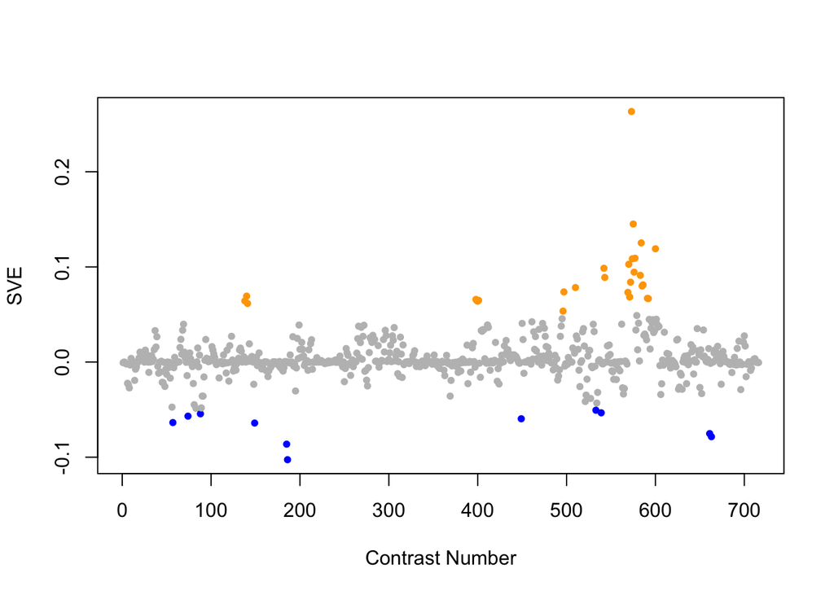

Positive SVE Contrasts:

|  | Contrast.Num | SVE | GEO.GSE | Cond.1 | Cond.2 | Mutation |
| --- | --- | --- | --- | --- | --- | --- |
| GSE2180.s1t2.vs.s1t1 | 573 | 0.26 | GSE2180 | 23-1 | 00B |  |
| GSE2180.s1t4.vs.s1t1 | 575 | 0.15 | GSE2180 | 53-1 | 00B |  |
| GSE2180.s2t4.vs.s2t1 | 584 | 0.13 | GSE2180 | ms53-4 | ms0-1 |  |
| GSE2180.s4t2.vs.s4t1 | 600 | 0.12 | GSE2180 | pp23-1 | pp0-1 |  |
| GSE2180.s1t6.vs.s1t1 | 577 | 0.11 | GSE2180 | 83-1 | 00B |  |
| GSE2180.s1t3.vs.s1t1 | 574 | 0.11 | GSE2180 | 41D | 00B |  |
| GSE2180.s1t8.vs.s1t1 | 570 | 0.10 | GSE2180 | 122-1 | 00B |  |
| GSE2180.s3t2.vs.s2t2 | 542 | 0.10 | GSE2180 | p23-2 | ms23-1 |  |
| GSE2180.s1t5.vs.s1t1 | 576 | 0.09 | GSE2180 | 66-4 | 00B |  |
| GSE2180.s2t3.vs.s2t1 | 583 | 0.09 | GSE2180 | ms41-1 | ms0-1 |  |
| GSE2180.s4t2.vs.s2t2 | 543 | 0.09 | GSE2180 | pp23-1 | ms23-1 |  |
| GSE2180.s1t10.vs.s1t1 | 572 | 0.08 | GSE2180 | 186-1 | 00B |  |
| GSE2180.s2t6.vs.s2t1 | 586 | 0.08 | GSE2180 | ms83-5 | ms0-1 |  |
| GSE2180.s2t5.vs.s2t1 | 585 | 0.08 | GSE2180 | ms66-3 | ms0-1 |  |
| GSE2180.s3t1.vs.s1t1 | 510 | 0.08 | GSE2180 | p0-3 | 00B | pie-1(zu154) |
| GSE23528C.s1t6.vs.s1t1 | 497 | 0.07 | GSE23528 | Adult at T46 in DD, time-series experiment 2 | Adult at T26 in DD, time-series experiment 2 |  |
| GSE2180.s1t7.vs.s1t1 | 569 | 0.07 | GSE2180 | 101G | 00B |  |
| GSE51691.s4t1.vs.s2t1 | 140 | 0.07 | GSE51691 | day8 hermaphrodite utx-1 RNAi +males rep 1 | day8 hermaphrodite +males rep 1 | utx-1(RNAi) |
| GSE2180.s1t9.vs.s1t1 | 571 | 0.07 | GSE2180 | 143L | 00B |  |
| GSE2180.s3t2.vs.s3t1 | 591 | 0.07 | GSE2180 | p23-2 | p0-3 |  |
| GSE2180.s3t3.vs.s3t1 | 592 | 0.07 | GSE2180 | p41-2 | p0-3 |  |
| GSE30505.s2t2.vs.s4t2 | 398 | 0.07 | GSE30505 | Day 8 N2 (WT) ash-2 #1 | Day 8 glp-1 ash-2 #1 | glp-1 |
| GSE30505.s1t2.vs.s3t2 | 401 | 0.06 | GSE30505 | Day 8 N2 (WT) E.V. #1 | Day 8 glp-1 E.V. #1 | glp-1 |
| GSE30505.s1t2.vs.s4t2 | 399 | 0.06 | GSE30505 | Day 8 N2 (WT) E.V. #1 | Day 8 glp-1 ash-2 #1 | glp-1; ash-2 |
| GSE51691.s4t1.vs.s1t1 | 138 | 0.06 | GSE51691 | day8 hermaphrodite utx-1 RNAi +males rep 1 | day8 hermaphrodite -males rep 1 |  |
| GSE30505.s2t2.vs.s3t2 | 400 | 0.06 | GSE30505 | Day 8 N2 (WT) ash-2 #1 | Day 8 glp-1 E.V. #1 | ash-2(RNAi) vs. glp-1 |
| GSE51691.s4t1.vs.s3t1 | 141 | 0.06 | GSE51691 | day8 hermaphrodite utx-1 RNAi +males rep 1 | day8 hermaphrodite utx-1 RNAi -males rep 1 |  |
| GSE23528C.s1t5.vs.s1t1 | 496 | 0.05 | GSE23528 | Adult at T42 in DD, time-series experiment 2 | Adult at T26 in DD, time-series experiment 2 |  |

Negative SVE Contrasts:

|  | Contrast.Num | SVE | GEO.GSE | Cond.1 | Cond.2 | Mutation |
| --- | --- | --- | --- | --- | --- | --- |
| GSE4766.s1t2.vs.s1t1 | 186 | -0.10 | GSE4766 | Pooled glp-1 C elegans young adults_rep1 | Pooled glp-1 C elegans embryos_bleach NaOH prep_rep1 |  |
| GSE4766.s1t3.vs.s1t1 | 185 | -0.09 | GSE4766 | Pooled glp-1 C elegans old adults_rep1 | Pooled glp-1 C elegans embryos_bleach NaOH prep_rep1 |  |
| GSE15159.s1t2.vs.s0t2 | 663 | -0.08 | GSE15159 | glp-1_UV_2007_rep1 | N2_UV_2007_rep1 | glp-1 |
| GSE15159.s1t1.vs.s0t1 | 661 | -0.08 | GSE15159 | glp-1_control_2007_rep1 | N2_control_2007_rep1 | glp-1 |
| GSE48347.s1t1.vs.s0t1 | 149 | -0.06 | GSE48347 | smo1_embryo_rep1 | WT_embryo_rep1 | smo-1 |
| GSE9665.s12t3.vs.s12t2 | 57 | -0.06 | GSE9665 | mex-3 vab-7 230 A | mex-3 vab-7 186 A |  |
| GSE25831.s1t1.vs.s2t1 | 449 | -0.06 | GSE25831 | WT_fedL1_rep1 | mixed embryo XX_WT-N_080307_A |  |
| GSE8231.s1t4.vs.s1t1 | 74 | -0.06 | GSE8231 | HLH-1 induction 6 hour replicate A (11-16-04_Krause_Celegans_H6A) | HLH-1 induction 0 hour replicate A (11-16-04_Krause_Celegans_H0A) |  |
| GSE6547.s0t2.vs.s0t1 | 88 | -0.05 | GSE6547 | N2 (wt) worms at L1 stage, first replicate | N2 (wt) worms at embryonic stage, first replicate |  |
| GSE2180.s2t2.vs.s1t2 | 539 | -0.05 | GSE2180 | ms23-1 | 23-1 | mex-3(zu155);skn-1(RNAi) |
| GSE2180.s2t10.vs.s1t10 | 533 | -0.05 | GSE2180 | ms186-5 | 186-1 | mex-3(zu155);skn-1(RNAi) |

$~$

#### Contrast SVE, Up-Regulated Genes Only:

Calculating SVE for up-regulated and down-regulated genes separately may be more informative in many cases than projecting the up- and down- gene sets together. This is due to the fact that the weight distribution of many modules is highly skewed, indicating that only one of the hemi-modules may be biologically meaningful (i.e., a set of genes are strongly correlated by only a few genes (or none) are strongly anti-correlated to that set.)

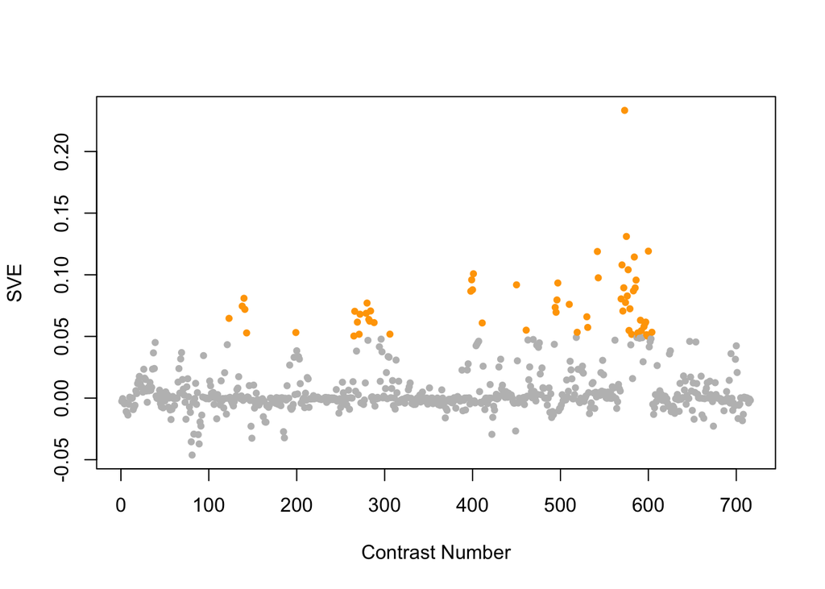

Positive SVE Contrasts:

|  | Contrast.Num | SVE | GEO.GSE | Cond.1 | Cond.2 | Mutation |
| --- | --- | --- | --- | --- | --- | --- |
| GSE2180.s1t2.vs.s1t1 | 573 | 0.23 | GSE2180 | 23-1 | 00B |  |
| GSE2180.s1t4.vs.s1t1 | 575 | 0.13 | GSE2180 | 53-1 | 00B |  |
| GSE2180.s4t2.vs.s4t1 | 600 | 0.12 | GSE2180 | pp23-1 | pp0-1 |  |
| GSE2180.s3t2.vs.s2t2 | 542 | 0.12 | GSE2180 | p23-2 | ms23-1 |  |
| GSE2180.s2t4.vs.s2t1 | 584 | 0.11 | GSE2180 | ms53-4 | ms0-1 |  |
| GSE2180.s1t8.vs.s1t1 | 570 | 0.11 | GSE2180 | 122-1 | 00B |  |
| GSE2180.s1t6.vs.s1t1 | 577 | 0.10 | GSE2180 | 83-1 | 00B |  |
| GSE30505.s1t2.vs.s3t2 | 401 | 0.10 | GSE30505 | Day 8 N2 (WT) E.V. #1 | Day 8 glp-1 E.V. #1 | glp-1 |
| GSE2180.s4t2.vs.s2t2 | 543 | 0.10 | GSE2180 | pp23-1 | ms23-1 |  |
| GSE30505.s1t2.vs.s4t2 | 399 | 0.10 | GSE30505 | Day 8 N2 (WT) E.V. #1 | Day 8 glp-1 ash-2 #1 | glp-1; ash-2 |
| GSE2180.s2t6.vs.s2t1 | 586 | 0.10 | GSE2180 | ms83-5 | ms0-1 |  |
| GSE23528C.s1t6.vs.s1t1 | 497 | 0.09 | GSE23528 | Adult at T46 in DD, time-series experiment 2 | Adult at T26 in DD, time-series experiment 2 |  |
| GSE25633.s2t1.vs.s3t1 | 450 | 0.09 | GSE25633 | daf-19,daf-12#1 | daf-12#1 | daf-19 |
| GSE2180.s1t10.vs.s1t1 | 572 | 0.09 | GSE2180 | 186-1 | 00B |  |
| GSE2180.s2t5.vs.s2t1 | 585 | 0.09 | GSE2180 | ms66-3 | ms0-1 |  |
| GSE30505.s2t2.vs.s3t2 | 400 | 0.09 | GSE30505 | Day 8 N2 (WT) ash-2 #1 | Day 8 glp-1 E.V. #1 | ash-2(RNAi) vs. glp-1 |
| GSE2180.s2t3.vs.s2t1 | 583 | 0.09 | GSE2180 | ms41-1 | ms0-1 |  |
| GSE30505.s2t2.vs.s4t2 | 398 | 0.09 | GSE30505 | Day 8 N2 (WT) ash-2 #1 | Day 8 glp-1 ash-2 #1 | glp-1 |
| GSE2180.s1t5.vs.s1t1 | 576 | 0.08 | GSE2180 | 66-4 | 00B |  |
| GSE51691.s4t1.vs.s2t1 | 140 | 0.08 | GSE51691 | day8 hermaphrodite utx-1 RNAi +males rep 1 | day8 hermaphrodite +males rep 1 | utx-1(RNAi) |
| GSE2180.s1t7.vs.s1t1 | 569 | 0.08 | GSE2180 | 101G | 00B |  |
| GSE23528C.s1t5.vs.s1t1 | 496 | 0.08 | GSE23528 | Adult at T42 in DD, time-series experiment 2 | Adult at T26 in DD, time-series experiment 2 |  |
| GSE2180.s1t3.vs.s1t1 | 574 | 0.08 | GSE2180 | 41D | 00B |  |
| GSE41366B.s0t3.vs.s0t1 | 280 | 0.08 | GSE41366 | control-8h_expose-26h_harvest-rep1 | control-8h_expose-14h_harvest-rep1 |  |
| GSE2180.s3t1.vs.s1t1 | 510 | 0.08 | GSE2180 | p0-3 | 00B | pie-1(zu154) |
| GSE51691.s4t1.vs.s1t1 | 138 | 0.07 | GSE51691 | day8 hermaphrodite utx-1 RNAi +males rep 1 | day8 hermaphrodite -males rep 1 |  |
| GSE23528C.s1t3.vs.s1t1 | 494 | 0.07 | GSE23528 | Adult at T34 in DD, time-series experiment 2 | Adult at T26 in DD, time-series experiment 2 |  |
| GSE2180.s2t8.vs.s2t1 | 579 | 0.07 | GSE2180 | ms122-1 | ms0-1 |  |
| GSE51691.s4t1.vs.s3t1 | 141 | 0.07 | GSE51691 | day8 hermaphrodite utx-1 RNAi +males rep 1 | day8 hermaphrodite utx-1 RNAi -males rep 1 |  |
| GSE41366B.s1t3.vs.s1t1 | 284 | 0.07 | GSE41366 | low_DDVP-8h_expose-26h_harvest-rep1 | low_DDVP-8h_expose-14h_harvest-rep1 |  |
| GSE2180.s1t9.vs.s1t1 | 571 | 0.07 | GSE2180 | 143L | 00B |  |
| GSE41366A.s0t4.vs.s0t1 | 266 | 0.07 | GSE41366 | control-2h_expose-26h_harvest-rep1 | control-2h_expose-8h_harvest-rep1 |  |
| GSE23528C.s1t4.vs.s1t1 | 495 | 0.07 | GSE23528 | Adult at T38 in DD, time-series experiment 2 | Adult at T26 in DD, time-series experiment 2 |  |
| GSE41366B.s0t2.vs.s0t1 | 279 | 0.07 | GSE41366 | control-8h_expose-20h_harvest-rep1 | control-8h_expose-14h_harvest-rep1 |  |
| GSE41366A.s1t4.vs.s1t1 | 272 | 0.07 | GSE41366 | low_DDVP-2h_expose-26h_harvest-rep1 | low_DDVP-2h_expose-8h_harvest-rep1 |  |
| GSE2180.s3t9.vs.s2t9 | 530 | 0.07 | GSE2180 | p143-2 | ms143-2 |  |
| GSE54024.s2t1.vs.s3t1 | 123 | 0.06 | GSE54024 | Wild type young adults treated with 0.1mM paraquat, biological rep 1 | nuo-6(qm200) young adults, biological rep 1 |  |
| GSE41366B.s2t3.vs.s2t1 | 282 | 0.06 | GSE41366 | high_DDVP-8h_expose-26h_harvest-rep1 | high_DDVP-8h_expose-14h_harvest-rep1 |  |
| GSE2180.s3t2.vs.s3t1 | 591 | 0.06 | GSE2180 | p23-2 | p0-3 |  |
| GSE41366B.s1t2.vs.s1t1 | 283 | 0.06 | GSE41366 | low_DDVP-8h_expose-20h_harvest-rep1 | low_DDVP-8h_expose-14h_harvest-rep1 |  |
| GSE2180.s4t8.vs.s4t1 | 597 | 0.06 | GSE2180 | pp122-1 | pp0-1 |  |
| GSE41366A.s2t4.vs.s2t1 | 269 | 0.06 | GSE41366 | high_DDVP-2h_expose-26h_harvest-rep1 | high_DDVP-2h_expose-8h_harvest-rep1 |  |
| GSE41366C.s1t4.vs.s0t4 | 288 | 0.06 | GSE41366 | low_DDVP-continuous_expose-20h_harvest-rep1 | control-continuous_expose-14h_harvest-rep1 |  |
| GSE30505.s2t2.vs.s2t1 | 411 | 0.06 | GSE30505 | Day 8 N2 (WT) ash-2 #1 | L3 N2 (WT) ash-2 #1 |  |
| GSE2180.s4t7.vs.s4t1 | 596 | 0.06 | GSE2180 | pp101-1 | pp0-1 |  |
| GSE2180.s3t6.vs.s3t1 | 595 | 0.06 | GSE2180 | p83-2 | p0-3 |  |
| GSE2180.s4t9.vs.s2t9 | 531 | 0.06 | GSE2180 | pp143-1 | ms143-2 |  |
| GSE23528A.s1t3.vs.s0t3 | 461 | 0.06 | GSE23528 | Adult at T10 in LD, time-series experiment 3 | Adult at T10, non-entrained control time-series experiment 4 |  |
| GSE2180.s2t7.vs.s2t1 | 578 | 0.05 | GSE2180 | ms101-2 | ms0-1 |  |
| GSE2180.s3t3.vs.s3t1 | 592 | 0.05 | GSE2180 | p41-2 | p0-3 |  |
| GSE2180.s4t6.vs.s4t1 | 604 | 0.05 | GSE2180 | pp83-1 | pp0-1 |  |
| GSE2180.s4t7.vs.s2t7 | 519 | 0.05 | GSE2180 | pp101-1 | ms101-2 |  |
| GSE43959.s1t2.vs.s4t2 | 199 | 0.05 | GSE43959 | N2 gravid adult on E. coli OP50 rep 1 | N2 gravid adult on 1:1000 Comamonas DA1877 rep 1 |  |
| GSE2180.s3t8.vs.s3t1 | 588 | 0.05 | GSE2180 | p122-2 | p0-3 |  |
| GSE50513.s3t1.vs.s1t1 | 143 | 0.05 | GSE50513 | zip-2 OP50 - rep 1 | L4440 OP50 - rep 1 | zip-2 |
| GSE41366C.s1t5.vs.s1t1 | 306 | 0.05 | GSE41366 | low_DDVP-continuous_expose-26h_harvest-rep1 | low_DDVP-continuous_expose-2h_harvest-rep1 |  |
| GSE41366A.s1t3.vs.s1t1 | 271 | 0.05 | GSE41366 | low_DDVP-2h_expose-20h_harvest-rep1 | low_DDVP-2h_expose-8h_harvest-rep1 |  |
| GSE2180.s2t10.vs.s2t1 | 581 | 0.05 | GSE2180 | ms186-5 | ms0-1 |  |
| GSE2180.s4t9.vs.s4t1 | 598 | 0.05 | GSE2180 | pp143-1 | pp0-1 |  |
| GSE2180.s3t9.vs.s3t1 | 589 | 0.05 | GSE2180 | p143-2 | p0-3 |  |
| GSE41366A.s0t3.vs.s0t1 | 265 | 0.05 | GSE41366 | control-2h_expose-20h_harvest-rep1 | control-2h_expose-8h_harvest-rep1 |  |
| GSE2180.s4t10.vs.s4t1 | 599 | 0.05 | GSE2180 | pp186-1 | pp0-1 |  |

Negative SVE Contrasts:

|  | Contrast.Num | SVE | GEO.GSE | Cond.1 | Cond.2 | Mutation |
| --- | --- | --- | --- | --- | --- | --- |
| GSE8004.s2t2.vs.s2t1 | 81 | -0.05 | GSE8004 | Larval Reference, biological rep 1 of set 1 | Embryonic Reference, biological rep 1 of set 1 |  |
| GSE6547.s0t3.vs.s0t1 | 89 | -0.04 | GSE6547 | N2 (wt) worms at L4 stage, first replicate | N2 (wt) worms at embryonic stage, first replicate |  |
| GSE8004.s3t2.vs.s3t1 | 80 | -0.04 | GSE8004 | Larval Pan-neural, biological rep 1 of set 2 | Embryonic Pan-neural, biological rep 1 of set 1 |  |
| GSE48347.s1t1.vs.s0t1 | 149 | -0.03 | GSE48347 | smo1_embryo_rep1 | WT_embryo_rep1 | smo-1 |
| GSE4766.s1t2.vs.s1t1 | 186 | -0.03 | GSE4766 | Pooled glp-1 C elegans young adults_rep1 | Pooled glp-1 C elegans embryos_bleach NaOH prep_rep1 |  |

$~$

#### Contrast SVE, Down-Regulated Genes Only:

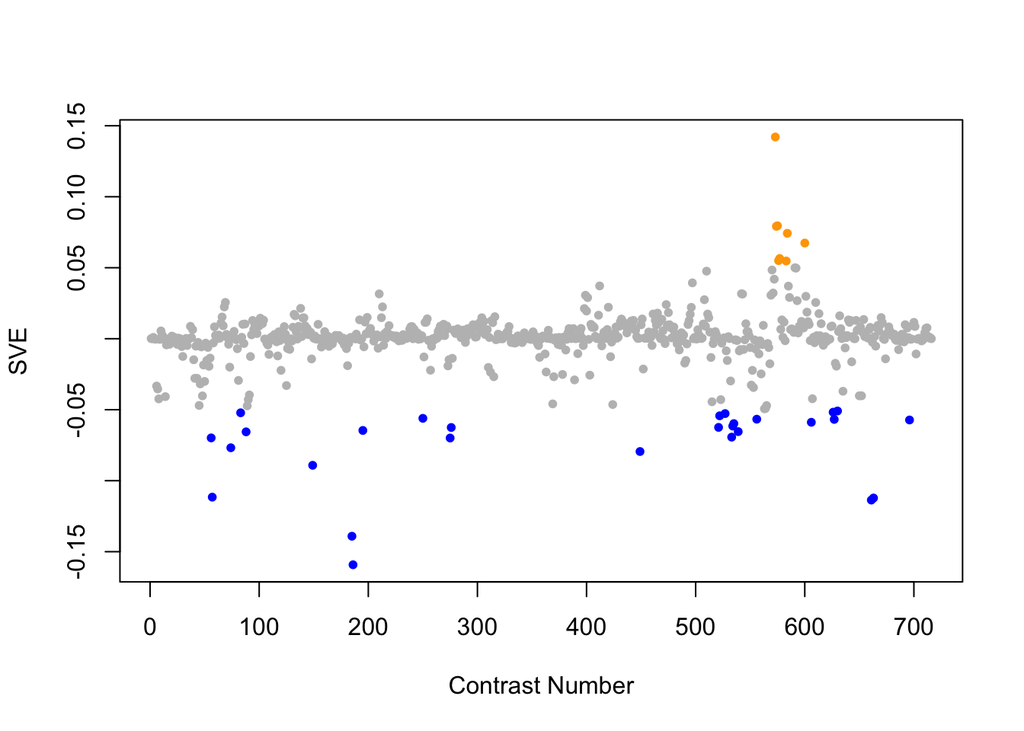

Positive SVE Contrasts:

|  | Contrast.Num | SVE | GEO.GSE | Cond.1 | Cond.2 | Mutation |
| --- | --- | --- | --- | --- | --- | --- |
| GSE2180.s1t2.vs.s1t1 | 573 | 0.14 | GSE2180 | 23-1 | 00B |  |
| GSE2180.s1t4.vs.s1t1 | 575 | 0.08 | GSE2180 | 53-1 | 00B |  |
| GSE2180.s1t3.vs.s1t1 | 574 | 0.08 | GSE2180 | 41D | 00B |  |
| GSE2180.s2t4.vs.s2t1 | 584 | 0.07 | GSE2180 | ms53-4 | ms0-1 |  |
| GSE2180.s4t2.vs.s4t1 | 600 | 0.07 | GSE2180 | pp23-1 | pp0-1 |  |
| GSE2180.s1t6.vs.s1t1 | 577 | 0.06 | GSE2180 | 83-1 | 00B |  |
| GSE2180.s1t5.vs.s1t1 | 576 | 0.06 | GSE2180 | 66-4 | 00B |  |
| GSE2180.s2t3.vs.s2t1 | 583 | 0.05 | GSE2180 | ms41-1 | ms0-1 |  |

Negative SVE Contrasts:

|  | Contrast.Num | SVE | GEO.GSE | Cond.1 | Cond.2 | Mutation |
| --- | --- | --- | --- | --- | --- | --- |
| GSE4766.s1t2.vs.s1t1 | 186 | -0.16 | GSE4766 | Pooled glp-1 C elegans young adults_rep1 | Pooled glp-1 C elegans embryos_bleach NaOH prep_rep1 |  |
| GSE4766.s1t3.vs.s1t1 | 185 | -0.14 | GSE4766 | Pooled glp-1 C elegans old adults_rep1 | Pooled glp-1 C elegans embryos_bleach NaOH prep_rep1 |  |
| GSE15159.s1t1.vs.s0t1 | 661 | -0.11 | GSE15159 | glp-1_control_2007_rep1 | N2_control_2007_rep1 | glp-1 |
| GSE15159.s1t2.vs.s0t2 | 663 | -0.11 | GSE15159 | glp-1_UV_2007_rep1 | N2_UV_2007_rep1 | glp-1 |
| GSE9665.s12t3.vs.s12t2 | 57 | -0.11 | GSE9665 | mex-3 vab-7 230 A | mex-3 vab-7 186 A |  |
| GSE48347.s1t1.vs.s0t1 | 149 | -0.09 | GSE48347 | smo1_embryo_rep1 | WT_embryo_rep1 | smo-1 |
| GSE25831.s1t1.vs.s2t1 | 449 | -0.08 | GSE25831 | WT_fedL1_rep1 | mixed embryo XX_WT-N_080307_A |  |
| GSE8231.s1t4.vs.s1t1 | 74 | -0.08 | GSE8231 | HLH-1 induction 6 hour replicate A (11-16-04_Krause_Celegans_H6A) | HLH-1 induction 0 hour replicate A (11-16-04_Krause_Celegans_H0A) |  |
| GSE41366B.s2t2.vs.s0t2 | 275 | -0.07 | GSE41366 | high_DDVP-8h_expose-20h_harvest-rep1 | control-8h_expose-20h_harvest-rep1 |  |
| GSE9665.s11t3.vs.s11t2 | 56 | -0.07 | GSE9665 | mex-3 unc-120 230 A | mex-3 unc-120 186 A |  |
| GSE2180.s2t10.vs.s1t10 | 533 | -0.07 | GSE2180 | ms186-5 | 186-1 | mex-3(zu155);skn-1(RNAi) |
| GSE6547.s0t2.vs.s0t1 | 88 | -0.07 | GSE6547 | N2 (wt) worms at L1 stage, first replicate | N2 (wt) worms at embryonic stage, first replicate |  |
| GSE2180.s2t2.vs.s1t2 | 539 | -0.07 | GSE2180 | ms23-1 | 23-1 | mex-3(zu155);skn-1(RNAi) |
| GSE43959.s2t1.vs.s3t1 | 195 | -0.06 | GSE43959 | N2 young adult on E. coli HT115 rep 1 | N2 young adult on Comamonas DA1877 rep 1 |  |
| GSE41366B.s1t2.vs.s0t2 | 276 | -0.06 | GSE41366 | low_DDVP-8h_expose-20h_harvest-rep1 | control-8h_expose-20h_harvest-rep1 |  |
| GSE2180.s2t8.vs.s1t8 | 521 | -0.06 | GSE2180 | ms122-1 | 122-1 | mex-3(zu155);skn-1(RNAi) |
| GSE2180.s3t10.vs.s1t10 | 534 | -0.06 | GSE2180 | p186-2 | 186-1 | pie-1(zu154) |
| GSE2180.s4t10.vs.s1t10 | 535 | -0.06 | GSE2180 | pp186-1 | 186-1 | pie-1(zu154);pal-1(RNAi) |
| GSE21784.s1t1.vs.s3t1 | 606 | -0.06 | GSE21784 | L4 larvae, biological rep1 | day 15 adults, biological rep 1 |  |
| GSE11055.s1t7.vs.s5t7 | 696 | -0.06 | GSE11055 | L1-L2 larvae 15 hr after hatching in the presence of food | L1 larvae starved for 12 hr after hatching and then fed for 3 hr |  |
| GSE19310A.s5t1.vs.s0t1 | 627 | -0.06 | GSE19310 | dpy-9(e12) at iso, rep1 | N2 at iso, rep1 | dpy-9 |
| GSE2180.s4t4.vs.s3t4 | 556 | -0.06 | GSE2180 | pp53-1 | p53-2 |  |
| GSE42192.s1t1.vs.s0t1 | 250 | -0.06 | GSE42192 | C.elegans fed with CNCM I-3690 3 days rep1 | C.elegans fed with E.coli OP50 3 days rep1 |  |
| GSE2180.s3t8.vs.s1t8 | 522 | -0.05 | GSE2180 | p122-2 | 122-1 | pie-1(zu154) |
| GSE2180.s2t9.vs.s1t9 | 527 | -0.05 | GSE2180 | ms143-2 | 143L | mex-3(zu155);skn-1(RNAi) |
| GSE6563.s1t1.vs.s0t1 | 83 | -0.05 | GSE6563 | daf19(m86)_daf12(sa204) replicate 1 | daf19(WT)_daf12(sa204) replicate 1 | daf-19 |
| GSE19310A.s4t1.vs.s0t1 | 626 | -0.05 | GSE19310 | dpy-10(e128) at iso, rep3 | N2 at iso, rep1 | dpy-10 |
| GSE19310A.s3t1.vs.s0t1 | 630 | -0.05 | GSE19310 | osm-8(n1518) at iso, rep1 | N2 at iso, rep1 | osm-8 |

$~$

$~$

#### GO Term Enrichment:

This analysis tests each hemi-module for enrichment of specific GO terms. Only gene-level annotations (e.g., as would be found on the gene’s page in Wormbase) are tested - the hierarchical structure of the GO ontology is not taken into account.

*Note: At least the top two most enriched terms from each GO domain (BP/MF/CC) are shown, even when not statistically significant.*

##### Enriched GO terms: Hemi-module A

| ID | GO.Term | GO Domain | Raw p-value | Adj p-value |
| --- | --- | --- | --- | --- |
| [GO_0007049](http://amigo.geneontology.org/amigo/term/GO:0007049) | cell cycle | BP | 3.34e-32 | 1.22e-28 |
| [GO_0051301](http://amigo.geneontology.org/amigo/term/GO:0051301) | cell division | BP | 1.16e-27 | 2.12e-24 |
| [GO_0000398](http://amigo.geneontology.org/amigo/term/GO:0000398) | mRNA splicing, via spliceosome | BP | 3.12e-27 | 3.79e-24 |
| [GO_0006260](http://amigo.geneontology.org/amigo/term/GO:0006260) | DNA replication | BP | 9.16e-24 | 8.34e-21 |
| [GO_0000070](http://amigo.geneontology.org/amigo/term/GO:0000070) | mitotic sister chromatid segregation | BP | 7.88e-22 | 5.74e-19 |
| [GO_0051321](http://amigo.geneontology.org/amigo/term/GO:0051321) | meiotic cell cycle | BP | 3.38e-19 | 2.05e-16 |
| [GO_0008380](http://amigo.geneontology.org/amigo/term/GO:0008380) | RNA splicing | BP | 5.37e-14 | 2.79e-11 |
| [GO_0006397](http://amigo.geneontology.org/amigo/term/GO:0006397) | mRNA processing | BP | 1.36e-12 | 6.21e-10 |
| [GO_0009792](http://amigo.geneontology.org/amigo/term/GO:0009792) | embryo development ending in birth or egg hatching | BP | 1.78e-11 | 7.22e-09 |
| [GO_0006396](http://amigo.geneontology.org/amigo/term/GO:0006396) | RNA processing | BP | 3.56e-11 | 1.30e-08 |
| [GO_0030261](http://amigo.geneontology.org/amigo/term/GO:0030261) | chromosome condensation | BP | 4.69e-10 | 1.55e-07 |
| [GO_0000727](http://amigo.geneontology.org/amigo/term/GO:0000727) | double-strand break repair via break-induced replication | BP | 5.25e-10 | 1.59e-07 |
| [GO_0006325](http://amigo.geneontology.org/amigo/term/GO:0006325) | chromatin organization | BP | 1.35e-09 | 3.78e-07 |
| [GO_0051028](http://amigo.geneontology.org/amigo/term/GO:0051028) | mRNA transport | BP | 1.54e-09 | 3.88e-07 |
| [GO_0000278](http://amigo.geneontology.org/amigo/term/GO:0000278) | mitotic cell cycle | BP | 1.70e-09 | 3.88e-07 |
| [GO_0034501](http://amigo.geneontology.org/amigo/term/GO:0034501) | protein localization to kinetochore | BP | 1.71e-09 | 3.88e-07 |
| [GO_0000212](http://amigo.geneontology.org/amigo/term/GO:0000212) | meiotic spindle organization | BP | 1.07e-08 | 2.17e-06 |
| [GO_0006270](http://amigo.geneontology.org/amigo/term/GO:0006270) | DNA replication initiation | BP | 1.07e-08 | 2.17e-06 |
| [GO_0000132](http://amigo.geneontology.org/amigo/term/GO:0000132) | establishment of mitotic spindle orientation | BP | 8.27e-08 | 1.59e-05 |
| [GO_0007094](http://amigo.geneontology.org/amigo/term/GO:0007094) | mitotic spindle assembly checkpoint | BP | 1.03e-07 | 1.85e-05 |
| [GO_0006267](http://amigo.geneontology.org/amigo/term/GO:0006267) | pre-replicative complex assembly involved in nuclear cell cycle DNA replication | BP | 1.12e-07 | 1.85e-05 |
| [GO_0007079](http://amigo.geneontology.org/amigo/term/GO:0007079) | mitotic chromosome movement towards spindle pole | BP | 1.12e-07 | 1.85e-05 |
| [GO_0006261](http://amigo.geneontology.org/amigo/term/GO:0006261) | DNA-dependent DNA replication | BP | 2.22e-07 | 3.51e-05 |
| [GO_0051257](http://amigo.geneontology.org/amigo/term/GO:0051257) | meiotic spindle midzone assembly | BP | 3.83e-07 | 5.70e-05 |
| [GO_0007186](http://amigo.geneontology.org/amigo/term/GO:0007186) | G protein-coupled receptor signaling pathway | BP | 3.92e-07 | 5.70e-05 |
| [GO_0007275](http://amigo.geneontology.org/amigo/term/GO:0007275) | multicellular organism development | BP | 4.07e-07 | 5.70e-05 |
| [GO_0006997](http://amigo.geneontology.org/amigo/term/GO:0006997) | nucleus organization | BP | 5.73e-07 | 7.72e-05 |
| [GO_0008608](http://amigo.geneontology.org/amigo/term/GO:0008608) | attachment of spindle microtubules to kinetochore | BP | 6.72e-07 | 8.75e-05 |
| [GO_0051382](http://amigo.geneontology.org/amigo/term/GO:0051382) | kinetochore assembly | BP | 9.97e-07 | 1.25e-04 |
| [GO_0006281](http://amigo.geneontology.org/amigo/term/GO:0006281) | DNA repair | BP | 1.08e-06 | 1.32e-04 |

[output cut: 168 more lines]

##### Enriched GO terms: Hemi-module B

| ID | GO.Term | GO Domain | Raw p-value | Adj p-value |
| --- | --- | --- | --- | --- |
| [GO_0005978](http://amigo.geneontology.org/amigo/term/GO:0005978) | glycogen biosynthetic process | BP | 1.96e-05 | 7.14e-02 |
| [GO_0006457](http://amigo.geneontology.org/amigo/term/GO:0006457) | protein folding | BP | 8.61e-05 | 1.10e-01 |
| [GO_0000166](http://amigo.geneontology.org/amigo/term/GO:0000166) | nucleotide binding | MF | 6.29e-04 | 6.44e-01 |
| [GO_0016874](http://amigo.geneontology.org/amigo/term/GO:0016874) | ligase activity | MF | 8.97e-04 | 6.44e-01 |
| [GO_0005737](http://amigo.geneontology.org/amigo/term/GO:0005737) | cytoplasm | CC | 1.64e-06 | 9.85e-04 |
| [GO_0005739](http://amigo.geneontology.org/amigo/term/GO:0005739) | mitochondrion | CC | 2.12e-06 | 9.85e-04 |
| [GO_0005829](http://amigo.geneontology.org/amigo/term/GO:0005829) | cytosol | CC | 9.76e-06 | 3.02e-03 |
| [GO_1990904](http://amigo.geneontology.org/amigo/term/GO:1990904) | ribonucleoprotein complex | CC | 3.39e-04 | 7.86e-02 |

$~$

$~$

#### Tissue Enrichment:

This analysis tests each hemi-module for enrichment of genes associated with anatomy terms. Negative enrichment scores indicate fewer hemi-module genes than expected by random chance were associated with the anatomy term in question.

##### Enriched tissues: Hemi-module A

| ID | Anatomy.Term | Definition | Raw p-value | Adj p-value |
| --- | --- | --- | --- | --- |
| [WBbt_0004017](https://wormbase.org/species/all/anatomy_term/WBbt:0004017) | Cell | a cellular object that consists of subcellular components, expresses genes or functions. | 5.47e-15 | 1.33e-11 |
| [WBbt_0005784](https://wormbase.org/species/all/anatomy_term/WBbt:0005784) | germ line | cell line which early in development becomes differentiated from the remaining somatic cell line, and alone has the potential to undergo meiosis and form gametes. | 1.83e-12 | 2.22e-09 |
| [WBbt_0004015](https://wormbase.org/species/all/anatomy_term/WBbt:0004015) | AB | Embryonic founder cell | 3.81e-07 | 3.09e-04 |
| [WBbt_0008378](https://wormbase.org/species/all/anatomy_term/WBbt:0008378) | somatic cell | Nucleated cell which has a diploid set of chromosomes. | 2.23e-05 | 1.36e-02 |
| [WBbt_0005741](https://wormbase.org/species/all/anatomy_term/WBbt:0005741) | tail | posterior region, from rectum to the end | 1.86e-04 | 9.05e-02 |

##### Enriched tissues: Hemi-module B

| ID | Anatomy.Term | Definition | Raw p-value | Adj p-value |
| --- | --- | --- | --- | --- |
| [WBbt_0005813](https://wormbase.org/species/all/anatomy_term/WBbt:0005813) | body wall musculature | Longitudinal bands of muscle cells surrounding animal body, with one band running in each quadrant of the body, regulated contraction and relaxation of these muscles cause locomotion. | 4.10e-05 | 9.98e-02 |

$~$

$~$

#### HOMER promoter motif enrichment:

This analysis tests each hemi-module for enrichment of 108 known *C. elegans* transcription factor binding site motifs (see [108 CE motifs](https://katiepod.github.io//all.worm.motifs.html)) using the HOMER (Hypergeometric Optimization of Motif EnRichment) software (see [PMID:20513432](https://pubmed.ncbi.nlm.nih.gov/20513432)). HOMER was run using default parameters on sequences 1 kb upstream of the transcription start site.

##### Motif enrichment: Hemi-module A

Total target sequences = 382  
Total background sequences = 36438  
* - possible false positive

Rank

Motif

P-value

log P-pvalue

% of Targets

% of Background

STD(Bg STD)

Best Match/Details

Motif File

1

[figure not shown]

1e-25

-5.967e+01

19.90%

4.59%

230.1bp (388.6bp)

LIN-15B(Zf)/cElegans-L3-LIN15B-ChIP-Seq(modEncode)/Homer(0.772)  
[More Information](https://katiepod.github.io/HomerResults/m73_a_hemi_genes.txt.out.1kb/homerResults/motif1.info.html) | [Similar Motifs Found](https://katiepod.github.io/HomerResults/m73_a_hemi_genes.txt.out.1kb/homerResults/motif1.similar.html)

[motif file (matrix)](https://katiepod.github.io/HomerResults/m73_a_hemi_genes.txt.out.1kb/homerResults/motif1.motif)

2

[figure not shown]

1e-20

-4.833e+01

9.42%

1.09%

211.6bp (402.6bp)

efl-1/MA0541.1/Jaspar(0.847)  
[More Information](https://katiepod.github.io/HomerResults/m73_a_hemi_genes.txt.out.1kb/homerResults/motif2.info.html) | [Similar Motifs Found](https://katiepod.github.io/HomerResults/m73_a_hemi_genes.txt.out.1kb/homerResults/motif2.similar.html)

[motif file (matrix)](https://katiepod.github.io/HomerResults/m73_a_hemi_genes.txt.out.1kb/homerResults/motif2.motif)

3

[figure not shown]

1e-15

-3.646e+01

35.86%

18.00%

290.9bp (405.9bp)

ceh-28/MA1445.1/Jaspar(0.935)  
[More Information](https://katiepod.github.io/HomerResults/m73_a_hemi_genes.txt.out.1kb/homerResults/motif3.info.html) | [Similar Motifs Found](https://katiepod.github.io/HomerResults/m73_a_hemi_genes.txt.out.1kb/homerResults/motif3.similar.html)

[motif file (matrix)](https://katiepod.github.io/HomerResults/m73_a_hemi_genes.txt.out.1kb/homerResults/motif3.motif)

4

[figure not shown]

1e-13

-3.223e+01

10.21%

2.22%

290.9bp (369.0bp)

blmp-1/MA0537.1/Jaspar(0.514)  
[More Information](https://katiepod.github.io/HomerResults/m73_a_hemi_genes.txt.out.1kb/homerResults/motif4.info.html) | [Similar Motifs Found](https://katiepod.github.io/HomerResults/m73_a_hemi_genes.txt.out.1kb/homerResults/motif4.similar.html)

[motif file (matrix)](https://katiepod.github.io/HomerResults/m73_a_hemi_genes.txt.out.1kb/homerResults/motif4.motif)

5

[figure not shown]

1e-13

-3.214e+01

41.10%

23.25%

287.3bp (382.4bp)

DPL-1(E2F)/cElegans-Adult-ChIP-Seq(modEncode)/Homer(0.600)  
[More Information](https://katiepod.github.io/HomerResults/m73_a_hemi_genes.txt.out.1kb/homerResults/motif5.info.html) | [Similar Motifs Found](https://katiepod.github.io/HomerResults/m73_a_hemi_genes.txt.out.1kb/homerResults/motif5.similar.html)

[motif file (matrix)](https://katiepod.github.io/HomerResults/m73_a_hemi_genes.txt.out.1kb/homerResults/motif5.motif)

6

[figure not shown]

1e-12

-2.803e+01

19.37%

7.82%

248.8bp (364.6bp)

PL0008.1_hlh-29/Jaspar(0.574)  
[More Information](https://katiepod.github.io/HomerResults/m73_a_hemi_genes.txt.out.1kb/homerResults/motif6.info.html) | [Similar Motifs Found](https://katiepod.github.io/HomerResults/m73_a_hemi_genes.txt.out.1kb/homerResults/motif6.similar.html)

[motif file (matrix)](https://katiepod.github.io/HomerResults/m73_a_hemi_genes.txt.out.1kb/homerResults/motif6.motif)

7 *

[figure not shown]

1e-11

-2.756e+01

9.95%

2.46%

278.7bp (382.3bp)

POL011.1_XCPE1/Jaspar(0.563)  
[More Information](https://katiepod.github.io/HomerResults/m73_a_hemi_genes.txt.out.1kb/homerResults/motif7.info.html) | [Similar Motifs Found](https://katiepod.github.io/HomerResults/m73_a_hemi_genes.txt.out.1kb/homerResults/motif7.similar.html)

[motif file (matrix)](https://katiepod.github.io/HomerResults/m73_a_hemi_genes.txt.out.1kb/homerResults/motif7.motif)

8 *

[figure not shown]

1e-11

-2.748e+01

5.24%

0.61%

311.4bp (384.3bp)

pha-4/MA0546.1/Jaspar(0.678)  
[More Information](https://katiepod.github.io/HomerResults/m73_a_hemi_genes.txt.out.1kb/homerResults/motif8.info.html) | [Similar Motifs Found](https://katiepod.github.io/HomerResults/m73_a_hemi_genes.txt.out.1kb/homerResults/motif8.similar.html)

[motif file (matrix)](https://katiepod.github.io/HomerResults/m73_a_hemi_genes.txt.out.1kb/homerResults/motif8.motif)

9 *

[figure not shown]

1e-11

-2.708e+01

24.87%

11.79%

281.1bp (381.4bp)

POL009.1_DCE_S_II/Jaspar(0.612)  
[More Information](https://katiepod.github.io/HomerResults/m73_a_hemi_genes.txt.out.1kb/homerResults/motif9.info.html) | [Similar Motifs Found](https://katiepod.github.io/HomerResults/m73_a_hemi_genes.txt.out.1kb/homerResults/motif9.similar.html)

[motif file (matrix)](https://katiepod.github.io/HomerResults/m73_a_hemi_genes.txt.out.1kb/homerResults/motif9.motif)

10 *

[figure not shown]

1e-11

-2.645e+01

19.37%

8.09%

271.2bp (399.2bp)

PL0018.1_hlh-25/Jaspar(0.567)  
[More Information](https://katiepod.github.io/HomerResults/m73_a_hemi_genes.txt.out.1kb/homerResults/motif10.info.html) | [Similar Motifs Found](https://katiepod.github.io/HomerResults/m73_a_hemi_genes.txt.out.1kb/homerResults/motif10.similar.html)

[motif file (matrix)](https://katiepod.github.io/HomerResults/m73_a_hemi_genes.txt.out.1kb/homerResults/motif10.motif)

11 *

[figure not shown]

1e-11

-2.622e+01

10.21%

2.71%

278.4bp (395.4bp)

cebp-1/MA1444.1/Jaspar(0.781)  
[More Information](https://katiepod.github.io/HomerResults/m73_a_hemi_genes.txt.out.1kb/homerResults/motif11.info.html) | [Similar Motifs Found](https://katiepod.github.io/HomerResults/m73_a_hemi_genes.txt.out.1kb/homerResults/motif11.similar.html)

[motif file (matrix)](https://katiepod.github.io/HomerResults/m73_a_hemi_genes.txt.out.1kb/homerResults/motif11.motif)

12 *

[figure not shown]

1e-11

-2.556e+01

30.89%

16.69%

285.4bp (333.0bp)

MF0005.1_Forkhead_class/Jaspar(0.666)  
[More Information](https://katiepod.github.io/HomerResults/m73_a_hemi_genes.txt.out.1kb/homerResults/motif12.info.html) | [Similar Motifs Found](https://katiepod.github.io/HomerResults/m73_a_hemi_genes.txt.out.1kb/homerResults/motif12.similar.html)

[motif file (matrix)](https://katiepod.github.io/HomerResults/m73_a_hemi_genes.txt.out.1kb/homerResults/motif12.motif)

13 *

[figure not shown]

1e-10

-2.464e+01

4.71%

0.55%

260.3bp (374.4bp)

PL0004.1_hlh-27/Jaspar(0.608)  
[More Information](https://katiepod.github.io/HomerResults/m73_a_hemi_genes.txt.out.1kb/homerResults/motif13.info.html) | [Similar Motifs Found](https://katiepod.github.io/HomerResults/m73_a_hemi_genes.txt.out.1kb/homerResults/motif13.similar.html)

[motif file (matrix)](https://katiepod.github.io/HomerResults/m73_a_hemi_genes.txt.out.1kb/homerResults/motif13.motif)

14 *

[figure not shown]

1e-10

-2.442e+01

8.90%

2.23%

238.2bp (364.0bp)

ceh-48/MA0921.1/Jaspar(0.636)  
[More Information](https://katiepod.github.io/HomerResults/m73_a_hemi_genes.txt.out.1kb/homerResults/motif14.info.html) | [Similar Motifs Found](https://katiepod.github.io/HomerResults/m73_a_hemi_genes.txt.out.1kb/homerResults/motif14.similar.html)

[motif file (matrix)](https://katiepod.github.io/HomerResults/m73_a_hemi_genes.txt.out.1kb/homerResults/motif14.motif)

15 *

[figure not shown]

1e-10

-2.334e+01

1.83%

0.02%

338.1bp (126.3bp)

POL010.1_DCE_S_III/Jaspar(0.533)  
[More Information](https://katiepod.github.io/HomerResults/m73_a_hemi_genes.txt.out.1kb/homerResults/motif15.info.html) | [Similar Motifs Found](https://katiepod.github.io/HomerResults/m73_a_hemi_genes.txt.out.1kb/homerResults/motif15.similar.html)

[motif file (matrix)](https://katiepod.github.io/HomerResults/m73_a_hemi_genes.txt.out.1kb/homerResults/motif15.motif)

16 *

[figure not shown]

1e-10

-2.311e+01

4.45%

0.53%

231.9bp (316.2bp)

PHA-4(Forkhead)/cElegans-Embryos-PHA4-ChIP-Seq(modEncode)/Homer(0.721)  
[More Information](https://katiepod.github.io/HomerResults/m73_a_hemi_genes.txt.out.1kb/homerResults/motif16.info.html) | [Similar Motifs Found](https://katiepod.github.io/HomerResults/m73_a_hemi_genes.txt.out.1kb/homerResults/motif16.similar.html)

[motif file (matrix)](https://katiepod.github.io/HomerResults/m73_a_hemi_genes.txt.out.1kb/homerResults/motif16.motif)

17 *

[figure not shown]

1e-9

-2.235e+01

3.66%

0.34%

255.9bp (330.8bp)

POL008.1_DCE_S_I/Jaspar(0.558)  
[More Information](https://katiepod.github.io/HomerResults/m73_a_hemi_genes.txt.out.1kb/homerResults/motif17.info.html) | [Similar Motifs Found](https://katiepod.github.io/HomerResults/m73_a_hemi_genes.txt.out.1kb/homerResults/motif17.similar.html)

[motif file (matrix)](https://katiepod.github.io/HomerResults/m73_a_hemi_genes.txt.out.1kb/homerResults/motif17.motif)

18 *

[figure not shown]

1e-9

-2.202e+01

6.54%

1.35%

229.2bp (352.4bp)

POL013.1_MED-1/Jaspar(0.530)  
[More Information](https://katiepod.github.io/HomerResults/m73_a_hemi_genes.txt.out.1kb/homerResults/motif18.info.html) | [Similar Motifs Found](https://katiepod.github.io/HomerResults/m73_a_hemi_genes.txt.out.1kb/homerResults/motif18.similar.html)

[motif file (matrix)](https://katiepod.github.io/HomerResults/m73_a_hemi_genes.txt.out.1kb/homerResults/motif18.motif)

19 *

[figure not shown]

1e-9

-2.178e+01

9.42%

2.75%

238.8bp (374.1bp)

MF0009.1_TRP(MYB)_class/Jaspar(0.631)  
[More Information](https://katiepod.github.io/HomerResults/m73_a_hemi_genes.txt.out.1kb/homerResults/motif19.info.html) | [Similar Motifs Found](https://katiepod.github.io/HomerResults/m73_a_hemi_genes.txt.out.1kb/homerResults/motif19.similar.html)

[motif file (matrix)](https://katiepod.github.io/HomerResults/m73_a_hemi_genes.txt.out.1kb/homerResults/motif19.motif)

20 *

[figure not shown]

1e-9

-2.152e+01

24.08%

12.46%

302.7bp (371.0bp)

pal-1/MA0924.1/Jaspar(0.709)  
[More Information](https://katiepod.github.io/HomerResults/m73_a_hemi_genes.txt.out.1kb/homerResults/motif20.info.html) | [Similar Motifs Found](https://katiepod.github.io/HomerResults/m73_a_hemi_genes.txt.out.1kb/homerResults/motif20.similar.html)

[motif file (matrix)](https://katiepod.github.io/HomerResults/m73_a_hemi_genes.txt.out.1kb/homerResults/motif20.motif)

21 *

[figure not shown]

1e-9

-2.136e+01

1.57%

0.01%

207.7bp (268.9bp)

POL009.1_DCE_S_II/Jaspar(0.552)  
[More Information](https://katiepod.github.io/HomerResults/m73_a_hemi_genes.txt.out.1kb/homerResults/motif21.info.html) | [Similar Motifs Found](https://katiepod.github.io/HomerResults/m73_a_hemi_genes.txt.out.1kb/homerResults/motif21.similar.html)

[motif file (matrix)](https://katiepod.github.io/HomerResults/m73_a_hemi_genes.txt.out.1kb/homerResults/motif21.motif)

22 *

[figure not shown]

1e-8

-1.877e+01

3.93%

0.54%

260.3bp (326.4bp)

MF0005.1_Forkhead_class/Jaspar(0.654)  
[More Information](https://katiepod.github.io/HomerResults/m73_a_hemi_genes.txt.out.1kb/homerResults/motif22.info.html) | [Similar Motifs Found](https://katiepod.github.io/HomerResults/m73_a_hemi_genes.txt.out.1kb/homerResults/motif22.similar.html)

[motif file (matrix)](https://katiepod.github.io/HomerResults/m73_a_hemi_genes.txt.out.1kb/homerResults/motif22.motif)

23 *

[figure not shown]

1e-7

-1.767e+01

21.20%

11.26%

273.6bp (369.3bp)

POL013.1_MED-1/Jaspar(0.637)  
[More Information](https://katiepod.github.io/HomerResults/m73_a_hemi_genes.txt.out.1kb/homerResults/motif23.info.html) | [Similar Motifs Found](https://katiepod.github.io/HomerResults/m73_a_hemi_genes.txt.out.1kb/homerResults/motif23.similar.html)

[motif file (matrix)](https://katiepod.github.io/HomerResults/m73_a_hemi_genes.txt.out.1kb/homerResults/motif23.motif)

24 *

[figure not shown]

1e-7

-1.673e+01

4.97%

1.05%

292.6bp (366.4bp)

blmp-1/MA0537.1/Jaspar(0.684)  
[More Information](https://katiepod.github.io/HomerResults/m73_a_hemi_genes.txt.out.1kb/homerResults/motif24.info.html) | [Similar Motifs Found](https://katiepod.github.io/HomerResults/m73_a_hemi_genes.txt.out.1kb/homerResults/motif24.similar.html)

[motif file (matrix)](https://katiepod.github.io/HomerResults/m73_a_hemi_genes.txt.out.1kb/homerResults/motif24.motif)

25 *

[figure not shown]

1e-7

-1.622e+01

19.11%

10.06%

280.9bp (362.2bp)

POL010.1_DCE_S_III/Jaspar(0.595)  
[More Information](https://katiepod.github.io/HomerResults/m73_a_hemi_genes.txt.out.1kb/homerResults/motif25.info.html) | [Similar Motifs Found](https://katiepod.github.io/HomerResults/m73_a_hemi_genes.txt.out.1kb/homerResults/motif25.similar.html)

[motif file (matrix)](https://katiepod.github.io/HomerResults/m73_a_hemi_genes.txt.out.1kb/homerResults/motif25.motif)

26 *

[figure not shown]

1e-6

-1.539e+01

4.45%

0.92%

236.1bp (326.6bp)

MF0006.1_bZIP_cEBP-like_subclass/Jaspar(0.557)  
[More Information](https://katiepod.github.io/HomerResults/m73_a_hemi_genes.txt.out.1kb/homerResults/motif26.info.html) | [Similar Motifs Found](https://katiepod.github.io/HomerResults/m73_a_hemi_genes.txt.out.1kb/homerResults/motif26.similar.html)

[motif file (matrix)](https://katiepod.github.io/HomerResults/m73_a_hemi_genes.txt.out.1kb/homerResults/motif26.motif)

27 *

[figure not shown]

1e-5

-1.244e+01

1.57%

0.10%

244.7bp (416.8bp)

fos-1/MA1448.1/Jaspar(0.541)  
[More Information](https://katiepod.github.io/HomerResults/m73_a_hemi_genes.txt.out.1kb/homerResults/motif27.info.html) | [Similar Motifs Found](https://katiepod.github.io/HomerResults/m73_a_hemi_genes.txt.out.1kb/homerResults/motif27.similar.html)

[motif file (matrix)](https://katiepod.github.io/HomerResults/m73_a_hemi_genes.txt.out.1kb/homerResults/motif27.motif)

28 *

[figure not shown]

1e-5

-1.225e+01

4.45%

1.17%

237.3bp (344.2bp)

ceh-48/MA0921.1/Jaspar(0.535)  
[More Information](https://katiepod.github.io/HomerResults/m73_a_hemi_genes.txt.out.1kb/homerResults/motif28.info.html) | [Similar Motifs Found](https://katiepod.github.io/HomerResults/m73_a_hemi_genes.txt.out.1kb/homerResults/motif28.similar.html)

[motif file (matrix)](https://katiepod.github.io/HomerResults/m73_a_hemi_genes.txt.out.1kb/homerResults/motif28.motif)

29 *

[figure not shown]

1e-5

-1.200e+01

18.32%

10.67%

303.8bp (352.9bp)

blmp-1/MA0537.1/Jaspar(0.597)  
[More Information](https://katiepod.github.io/HomerResults/m73_a_hemi_genes.txt.out.1kb/homerResults/motif29.info.html) | [Similar Motifs Found](https://katiepod.github.io/HomerResults/m73_a_hemi_genes.txt.out.1kb/homerResults/motif29.similar.html)

[motif file (matrix)](https://katiepod.github.io/HomerResults/m73_a_hemi_genes.txt.out.1kb/homerResults/motif29.motif)

30 *

[figure not shown]

1e-5

-1.193e+01

35.08%

24.90%

280.5bp (360.0bp)

fkh-9/MA1440.1/Jaspar(0.678)  
[More Information](https://katiepod.github.io/HomerResults/m73_a_hemi_genes.txt.out.1kb/homerResults/motif30.info.html) | [Similar Motifs Found](https://katiepod.github.io/HomerResults/m73_a_hemi_genes.txt.out.1kb/homerResults/motif30.similar.html)

[motif file (matrix)](https://katiepod.github.io/HomerResults/m73_a_hemi_genes.txt.out.1kb/homerResults/motif30.motif)

31 *

[figure not shown]

1e-4

-1.045e+01

4.71%

1.49%

259.0bp (324.7bp)

MF0002.1_bZIP_CREB/G-box-like_subclass/Jaspar(0.579)  
[More Information](https://katiepod.github.io/HomerResults/m73_a_hemi_genes.txt.out.1kb/homerResults/motif31.info.html) | [Similar Motifs Found](https://katiepod.github.io/HomerResults/m73_a_hemi_genes.txt.out.1kb/homerResults/motif31.similar.html)

[motif file (matrix)](https://katiepod.github.io/HomerResults/m73_a_hemi_genes.txt.out.1kb/homerResults/motif31.motif)

32 *

[figure not shown]

1e-3

-9.183e+00

1.05%

0.06%

257.6bp (190.9bp)

SD0002.1_at_AC_acceptor/Jaspar(0.528)  
[More Information](https://katiepod.github.io/HomerResults/m73_a_hemi_genes.txt.out.1kb/homerResults/motif32.info.html) | [Similar Motifs Found](https://katiepod.github.io/HomerResults/m73_a_hemi_genes.txt.out.1kb/homerResults/motif32.similar.html)

[motif file (matrix)](https://katiepod.github.io/HomerResults/m73_a_hemi_genes.txt.out.1kb/homerResults/motif32.motif)

33 *

[figure not shown]

1e-3

-8.255e+00

6.54%

2.97%

249.5bp (347.4bp)

POL013.1_MED-1/Jaspar(0.508)  
[More Information](https://katiepod.github.io/HomerResults/m73_a_hemi_genes.txt.out.1kb/homerResults/motif33.info.html) | [Similar Motifs Found](https://katiepod.github.io/HomerResults/m73_a_hemi_genes.txt.out.1kb/homerResults/motif33.similar.html)

[motif file (matrix)](https://katiepod.github.io/HomerResults/m73_a_hemi_genes.txt.out.1kb/homerResults/motif33.motif)

34 *

[figure not shown]

1e-3

-7.532e+00

1.57%

0.25%

129.7bp (282.2bp)

MF0007.1_bHLH(zip)_class/Jaspar(0.674)  
[More Information](https://katiepod.github.io/HomerResults/m73_a_hemi_genes.txt.out.1kb/homerResults/motif34.info.html) | [Similar Motifs Found](https://katiepod.github.io/HomerResults/m73_a_hemi_genes.txt.out.1kb/homerResults/motif34.similar.html)

[motif file (matrix)](https://katiepod.github.io/HomerResults/m73_a_hemi_genes.txt.out.1kb/homerResults/motif34.motif)

35 *

[figure not shown]

1e-1

-4.214e+00

1.31%

0.37%

223.7bp (352.7bp)

blmp-1/MA0537.1/Jaspar(0.613)  
[More Information](https://katiepod.github.io/HomerResults/m73_a_hemi_genes.txt.out.1kb/homerResults/motif35.info.html) | [Similar Motifs Found](https://katiepod.github.io/HomerResults/m73_a_hemi_genes.txt.out.1kb/homerResults/motif35.similar.html)

[motif file (matrix)](https://katiepod.github.io/HomerResults/m73_a_hemi_genes.txt.out.1kb/homerResults/motif35.motif)

36 *

[figure not shown]

1e0

-1.988e+00

8.12%

6.58%

239.6bp (354.4bp)

atf-7/MA1438.1/Jaspar(0.884)  
[More Information](https://katiepod.github.io/HomerResults/m73_a_hemi_genes.txt.out.1kb/homerResults/motif36.info.html) | [Similar Motifs Found](https://katiepod.github.io/HomerResults/m73_a_hemi_genes.txt.out.1kb/homerResults/motif36.similar.html)

[motif file (matrix)](https://katiepod.github.io/HomerResults/m73_a_hemi_genes.txt.out.1kb/homerResults/motif36.motif)

##### Motif enrichment: Hemi-module B

Total target sequences = 104  
Total background sequences = 36129  
* - possible false positive

Rank

Motif

P-value

log P-pvalue

% of Targets

% of Background

STD(Bg STD)

Best Match/Details

Motif File

1 *

[figure not shown]

1e-11

-2.554e+01

24.04%

4.58%

237.0bp (342.5bp)

ceh-38/MA1699.1/Jaspar(0.529)  
[More Information](https://katiepod.github.io/HomerResults/m73_b_hemi_genes.txt.out.1kb/homerResults/motif1.info.html) | [Similar Motifs Found](https://katiepod.github.io/HomerResults/m73_b_hemi_genes.txt.out.1kb/homerResults/motif1.similar.html)

[motif file (matrix)](https://katiepod.github.io/HomerResults/m73_b_hemi_genes.txt.out.1kb/homerResults/motif1.motif)

2 *

[figure not shown]

1e-11

-2.553e+01

16.35%

1.80%

231.0bp (299.9bp)

cebp-1/MA1444.1/Jaspar(0.564)  
[More Information](https://katiepod.github.io/HomerResults/m73_b_hemi_genes.txt.out.1kb/homerResults/motif2.info.html) | [Similar Motifs Found](https://katiepod.github.io/HomerResults/m73_b_hemi_genes.txt.out.1kb/homerResults/motif2.similar.html)

[motif file (matrix)](https://katiepod.github.io/HomerResults/m73_b_hemi_genes.txt.out.1kb/homerResults/motif2.motif)

3 *

[figure not shown]

1e-10

-2.457e+01

31.73%

8.59%

288.6bp (354.4bp)

fkh-9/MA1440.1/Jaspar(0.695)  
[More Information](https://katiepod.github.io/HomerResults/m73_b_hemi_genes.txt.out.1kb/homerResults/motif3.info.html) | [Similar Motifs Found](https://katiepod.github.io/HomerResults/m73_b_hemi_genes.txt.out.1kb/homerResults/motif3.similar.html)

[motif file (matrix)](https://katiepod.github.io/HomerResults/m73_b_hemi_genes.txt.out.1kb/homerResults/motif3.motif)

4 *

[figure not shown]

1e-10

-2.397e+01

6.73%

0.10%

183.0bp (274.6bp)

daf-12/MA0538.1/Jaspar(0.547)  
[More Information](https://katiepod.github.io/HomerResults/m73_b_hemi_genes.txt.out.1kb/homerResults/motif4.info.html) | [Similar Motifs Found](https://katiepod.github.io/HomerResults/m73_b_hemi_genes.txt.out.1kb/homerResults/motif4.similar.html)

[motif file (matrix)](https://katiepod.github.io/HomerResults/m73_b_hemi_genes.txt.out.1kb/homerResults/motif4.motif)

5 *

[figure not shown]

1e-10

-2.361e+01

11.54%

0.78%

283.2bp (349.5bp)

MF0001.1_ETS_class/Jaspar(0.679)  
[More Information](https://katiepod.github.io/HomerResults/m73_b_hemi_genes.txt.out.1kb/homerResults/motif5.info.html) | [Similar Motifs Found](https://katiepod.github.io/HomerResults/m73_b_hemi_genes.txt.out.1kb/homerResults/motif5.similar.html)

[motif file (matrix)](https://katiepod.github.io/HomerResults/m73_b_hemi_genes.txt.out.1kb/homerResults/motif5.motif)

6 *

[figure not shown]

1e-10

-2.349e+01

9.62%

0.44%

191.2bp (353.5bp)

MF0010.1_Homeobox_class/Jaspar(0.680)  
[More Information](https://katiepod.github.io/HomerResults/m73_b_hemi_genes.txt.out.1kb/homerResults/motif6.info.html) | [Similar Motifs Found](https://katiepod.github.io/HomerResults/m73_b_hemi_genes.txt.out.1kb/homerResults/motif6.similar.html)

[motif file (matrix)](https://katiepod.github.io/HomerResults/m73_b_hemi_genes.txt.out.1kb/homerResults/motif6.motif)

7 *

[figure not shown]

1e-9

-2.269e+01

18.27%

2.84%

270.4bp (311.4bp)

EGL-5(Homeobox)/cElegans-L3-EGL5-ChIP-Seq(modEncode)/Homer(0.640)  
[More Information](https://katiepod.github.io/HomerResults/m73_b_hemi_genes.txt.out.1kb/homerResults/motif7.info.html) | [Similar Motifs Found](https://katiepod.github.io/HomerResults/m73_b_hemi_genes.txt.out.1kb/homerResults/motif7.similar.html)

[motif file (matrix)](https://katiepod.github.io/HomerResults/m73_b_hemi_genes.txt.out.1kb/homerResults/motif7.motif)

8 *

[figure not shown]

1e-9

-2.132e+01

23.08%

5.15%

260.1bp (343.9bp)

blmp-1/MA0537.1/Jaspar(0.573)  
[More Information](https://katiepod.github.io/HomerResults/m73_b_hemi_genes.txt.out.1kb/homerResults/motif8.info.html) | [Similar Motifs Found](https://katiepod.github.io/HomerResults/m73_b_hemi_genes.txt.out.1kb/homerResults/motif8.similar.html)

[motif file (matrix)](https://katiepod.github.io/HomerResults/m73_b_hemi_genes.txt.out.1kb/homerResults/motif8.motif)

9 *

[figure not shown]

1e-9

-2.130e+01

18.27%

3.09%

339.7bp (322.1bp)

POL012.1_TATA-Box/Jaspar(0.627)  
[More Information](https://katiepod.github.io/HomerResults/m73_b_hemi_genes.txt.out.1kb/homerResults/motif9.info.html) | [Similar Motifs Found](https://katiepod.github.io/HomerResults/m73_b_hemi_genes.txt.out.1kb/homerResults/motif9.similar.html)

[motif file (matrix)](https://katiepod.github.io/HomerResults/m73_b_hemi_genes.txt.out.1kb/homerResults/motif9.motif)

10 *

[figure not shown]

1e-9

-2.102e+01

10.58%

0.76%

300.4bp (341.7bp)

POL009.1_DCE_S_II/Jaspar(0.613)  
[More Information](https://katiepod.github.io/HomerResults/m73_b_hemi_genes.txt.out.1kb/homerResults/motif10.info.html) | [Similar Motifs Found](https://katiepod.github.io/HomerResults/m73_b_hemi_genes.txt.out.1kb/homerResults/motif10.similar.html)

[motif file (matrix)](https://katiepod.github.io/HomerResults/m73_b_hemi_genes.txt.out.1kb/homerResults/motif10.motif)

11 *

[figure not shown]

1e-8

-2.042e+01

12.50%

1.30%

204.7bp (317.6bp)

POL010.1_DCE_S_III/Jaspar(0.584)  
[More Information](https://katiepod.github.io/HomerResults/m73_b_hemi_genes.txt.out.1kb/homerResults/motif11.info.html) | [Similar Motifs Found](https://katiepod.github.io/HomerResults/m73_b_hemi_genes.txt.out.1kb/homerResults/motif11.similar.html)

[motif file (matrix)](https://katiepod.github.io/HomerResults/m73_b_hemi_genes.txt.out.1kb/homerResults/motif11.motif)

12 *

[figure not shown]

1e-8

-2.042e+01

6.73%

0.18%

269.2bp (327.6bp)

ceh-28/MA1445.1/Jaspar(0.683)  
[More Information](https://katiepod.github.io/HomerResults/m73_b_hemi_genes.txt.out.1kb/homerResults/motif12.info.html) | [Similar Motifs Found](https://katiepod.github.io/HomerResults/m73_b_hemi_genes.txt.out.1kb/homerResults/motif12.similar.html)

[motif file (matrix)](https://katiepod.github.io/HomerResults/m73_b_hemi_genes.txt.out.1kb/homerResults/motif12.motif)

13 *

[figure not shown]

1e-8

-2.034e+01

4.81%

0.04%

296.2bp (370.8bp)

PL0001.1_hlh-11/Jaspar(0.603)  
[More Information](https://katiepod.github.io/HomerResults/m73_b_hemi_genes.txt.out.1kb/homerResults/motif13.info.html) | [Similar Motifs Found](https://katiepod.github.io/HomerResults/m73_b_hemi_genes.txt.out.1kb/homerResults/motif13.similar.html)

[motif file (matrix)](https://katiepod.github.io/HomerResults/m73_b_hemi_genes.txt.out.1kb/homerResults/motif13.motif)

14 *

[figure not shown]

1e-7

-1.836e+01

8.65%

0.56%

198.7bp (343.1bp)

fkh-9/MA1440.1/Jaspar(0.642)  
[More Information](https://katiepod.github.io/HomerResults/m73_b_hemi_genes.txt.out.1kb/homerResults/motif14.info.html) | [Similar Motifs Found](https://katiepod.github.io/HomerResults/m73_b_hemi_genes.txt.out.1kb/homerResults/motif14.similar.html)

[motif file (matrix)](https://katiepod.github.io/HomerResults/m73_b_hemi_genes.txt.out.1kb/homerResults/motif14.motif)

15 *

[figure not shown]

1e-7

-1.689e+01

4.81%

0.08%

190.8bp (401.0bp)

unc-86/MA0926.1/Jaspar(0.529)  
[More Information](https://katiepod.github.io/HomerResults/m73_b_hemi_genes.txt.out.1kb/homerResults/motif15.info.html) | [Similar Motifs Found](https://katiepod.github.io/HomerResults/m73_b_hemi_genes.txt.out.1kb/homerResults/motif15.similar.html)

[motif file (matrix)](https://katiepod.github.io/HomerResults/m73_b_hemi_genes.txt.out.1kb/homerResults/motif15.motif)

16 *

[figure not shown]

1e-7

-1.682e+01

9.62%

0.90%

232.4bp (312.4bp)

lin-54/MA1450.1/Jaspar(0.546)  
[More Information](https://katiepod.github.io/HomerResults/m73_b_hemi_genes.txt.out.1kb/homerResults/motif16.info.html) | [Similar Motifs Found](https://katiepod.github.io/HomerResults/m73_b_hemi_genes.txt.out.1kb/homerResults/motif16.similar.html)

[motif file (matrix)](https://katiepod.github.io/HomerResults/m73_b_hemi_genes.txt.out.1kb/homerResults/motif16.motif)

17 *

[figure not shown]

1e-7

-1.653e+01

10.58%

1.20%

296.6bp (333.8bp)

cebp-1/MA1444.1/Jaspar(0.612)  
[More Information](https://katiepod.github.io/HomerResults/m73_b_hemi_genes.txt.out.1kb/homerResults/motif17.info.html) | [Similar Motifs Found](https://katiepod.github.io/HomerResults/m73_b_hemi_genes.txt.out.1kb/homerResults/motif17.similar.html)

[motif file (matrix)](https://katiepod.github.io/HomerResults/m73_b_hemi_genes.txt.out.1kb/homerResults/motif17.motif)

18 *

[figure not shown]

1e-7

-1.646e+01

15.38%

2.92%

276.0bp (342.8bp)

POL009.1_DCE_S_II/Jaspar(0.605)  
[More Information](https://katiepod.github.io/HomerResults/m73_b_hemi_genes.txt.out.1kb/homerResults/motif18.info.html) | [Similar Motifs Found](https://katiepod.github.io/HomerResults/m73_b_hemi_genes.txt.out.1kb/homerResults/motif18.similar.html)

[motif file (matrix)](https://katiepod.github.io/HomerResults/m73_b_hemi_genes.txt.out.1kb/homerResults/motif18.motif)

19 *

[figure not shown]

1e-7

-1.623e+01

8.65%

0.72%

245.8bp (332.9bp)

POL013.1_MED-1/Jaspar(0.509)  
[More Information](https://katiepod.github.io/HomerResults/m73_b_hemi_genes.txt.out.1kb/homerResults/motif19.info.html) | [Similar Motifs Found](https://katiepod.github.io/HomerResults/m73_b_hemi_genes.txt.out.1kb/homerResults/motif19.similar.html)

[motif file (matrix)](https://katiepod.github.io/HomerResults/m73_b_hemi_genes.txt.out.1kb/homerResults/motif19.motif)

20 *

[figure not shown]

1e-6

-1.608e+01

42.31%

19.58%

272.1bp (331.9bp)

mab-3/MA0262.1/Jaspar(0.683)  
[More Information](https://katiepod.github.io/HomerResults/m73_b_hemi_genes.txt.out.1kb/homerResults/motif20.info.html) | [Similar Motifs Found](https://katiepod.github.io/HomerResults/m73_b_hemi_genes.txt.out.1kb/homerResults/motif20.similar.html)

[motif file (matrix)](https://katiepod.github.io/HomerResults/m73_b_hemi_genes.txt.out.1kb/homerResults/motif20.motif)

21 *

[figure not shown]

1e-6

-1.592e+01

4.81%

0.10%

219.7bp (210.2bp)

SD0003.1_at_AC_acceptor/Jaspar(0.644)  
[More Information](https://katiepod.github.io/HomerResults/m73_b_hemi_genes.txt.out.1kb/homerResults/motif21.info.html) | [Similar Motifs Found](https://katiepod.github.io/HomerResults/m73_b_hemi_genes.txt.out.1kb/homerResults/motif21.similar.html)

[motif file (matrix)](https://katiepod.github.io/HomerResults/m73_b_hemi_genes.txt.out.1kb/homerResults/motif21.motif)

22 *

[figure not shown]

1e-6

-1.559e+01

45.19%

22.16%

269.6bp (347.4bp)

blmp-1/MA0537.1/Jaspar(0.692)  
[More Information](https://katiepod.github.io/HomerResults/m73_b_hemi_genes.txt.out.1kb/homerResults/motif22.info.html) | [Similar Motifs Found](https://katiepod.github.io/HomerResults/m73_b_hemi_genes.txt.out.1kb/homerResults/motif22.similar.html)

[motif file (matrix)](https://katiepod.github.io/HomerResults/m73_b_hemi_genes.txt.out.1kb/homerResults/motif22.motif)

23 *

[figure not shown]

1e-6

-1.420e+01

47.12%

24.77%

287.3bp (352.6bp)

eor-1/MA0543.1/Jaspar(0.623)  
[More Information](https://katiepod.github.io/HomerResults/m73_b_hemi_genes.txt.out.1kb/homerResults/motif23.info.html) | [Similar Motifs Found](https://katiepod.github.io/HomerResults/m73_b_hemi_genes.txt.out.1kb/homerResults/motif23.similar.html)

[motif file (matrix)](https://katiepod.github.io/HomerResults/m73_b_hemi_genes.txt.out.1kb/homerResults/motif23.motif)

24 *

[figure not shown]

1e-5

-1.374e+01

8.65%

0.98%

244.7bp (307.4bp)

che-1/MA0260.1/Jaspar(0.581)  
[More Information](https://katiepod.github.io/HomerResults/m73_b_hemi_genes.txt.out.1kb/homerResults/motif24.info.html) | [Similar Motifs Found](https://katiepod.github.io/HomerResults/m73_b_hemi_genes.txt.out.1kb/homerResults/motif24.similar.html)

[motif file (matrix)](https://katiepod.github.io/HomerResults/m73_b_hemi_genes.txt.out.1kb/homerResults/motif24.motif)

25 *

[figure not shown]

1e-5

-1.360e+01

3.85%

0.07%

166.8bp (267.5bp)

MF0010.1_Homeobox_class/Jaspar(0.772)  
[More Information](https://katiepod.github.io/HomerResults/m73_b_hemi_genes.txt.out.1kb/homerResults/motif25.info.html) | [Similar Motifs Found](https://katiepod.github.io/HomerResults/m73_b_hemi_genes.txt.out.1kb/homerResults/motif25.similar.html)

[motif file (matrix)](https://katiepod.github.io/HomerResults/m73_b_hemi_genes.txt.out.1kb/homerResults/motif25.motif)

26 *

[figure not shown]

1e-5

-1.327e+01

5.77%

0.33%

272.1bp (430.1bp)

skn-1/MA0547.1/Jaspar(0.455)  
[More Information](https://katiepod.github.io/HomerResults/m73_b_hemi_genes.txt.out.1kb/homerResults/motif26.info.html) | [Similar Motifs Found](https://katiepod.github.io/HomerResults/m73_b_hemi_genes.txt.out.1kb/homerResults/motif26.similar.html)

[motif file (matrix)](https://katiepod.github.io/HomerResults/m73_b_hemi_genes.txt.out.1kb/homerResults/motif26.motif)

27 *

[figure not shown]

1e-5

-1.311e+01

6.73%

0.54%

273.9bp (342.5bp)

ceh-28/MA1445.1/Jaspar(0.747)  
[More Information](https://katiepod.github.io/HomerResults/m73_b_hemi_genes.txt.out.1kb/homerResults/motif27.info.html) | [Similar Motifs Found](https://katiepod.github.io/HomerResults/m73_b_hemi_genes.txt.out.1kb/homerResults/motif27.similar.html)

[motif file (matrix)](https://katiepod.github.io/HomerResults/m73_b_hemi_genes.txt.out.1kb/homerResults/motif27.motif)

28 *

[figure not shown]

1e-5

-1.198e+01

39.42%

20.28%

292.7bp (346.5bp)

MF0001.1_ETS_class/Jaspar(0.566)  
[More Information](https://katiepod.github.io/HomerResults/m73_b_hemi_genes.txt.out.1kb/homerResults/motif28.info.html) | [Similar Motifs Found](https://katiepod.github.io/HomerResults/m73_b_hemi_genes.txt.out.1kb/homerResults/motif28.similar.html)

[motif file (matrix)](https://katiepod.github.io/HomerResults/m73_b_hemi_genes.txt.out.1kb/homerResults/motif28.motif)

29 *

[figure not shown]

1e-5

-1.181e+01

32.69%

15.25%

276.5bp (351.4bp)

MF0004.1_Nuclear_Receptor_class/Jaspar(0.593)  
[More Information](https://katiepod.github.io/HomerResults/m73_b_hemi_genes.txt.out.1kb/homerResults/motif29.info.html) | [Similar Motifs Found](https://katiepod.github.io/HomerResults/m73_b_hemi_genes.txt.out.1kb/homerResults/motif29.similar.html)

[motif file (matrix)](https://katiepod.github.io/HomerResults/m73_b_hemi_genes.txt.out.1kb/homerResults/motif29.motif)

30 *

[figure not shown]

1e-4

-1.092e+01

3.85%

0.14%

160.7bp (281.4bp)

PL0008.1_hlh-29/Jaspar(0.630)  
[More Information](https://katiepod.github.io/HomerResults/m73_b_hemi_genes.txt.out.1kb/homerResults/motif30.info.html) | [Similar Motifs Found](https://katiepod.github.io/HomerResults/m73_b_hemi_genes.txt.out.1kb/homerResults/motif30.similar.html)

[motif file (matrix)](https://katiepod.github.io/HomerResults/m73_b_hemi_genes.txt.out.1kb/homerResults/motif30.motif)

31 *

[figure not shown]

1e-4

-1.036e+01

4.81%

0.33%

218.9bp (332.3bp)

POL010.1_DCE_S_III/Jaspar(0.536)  
[More Information](https://katiepod.github.io/HomerResults/m73_b_hemi_genes.txt.out.1kb/homerResults/motif31.info.html) | [Similar Motifs Found](https://katiepod.github.io/HomerResults/m73_b_hemi_genes.txt.out.1kb/homerResults/motif31.similar.html)

[motif file (matrix)](https://katiepod.github.io/HomerResults/m73_b_hemi_genes.txt.out.1kb/homerResults/motif31.motif)

$~$

$~$

#### Promoter Word Enrichment:

This analysis tests each hemi-module for enrichment of specific promoter words. The list of promoter words tested was generated by running the MobyDick algorithm (see [PMID:10944202](https://pubmed.ncbi.nlm.nih.gov/10944202)) on the full set of *C. elegans* 2 Kbp promoters.

##### Enriched promoter words: Hemi-module A

| Word | RC | Raw.p.value | Adj.p.value |
| --- | --- | --- | --- |
| GCGCGC | GCGCGC | 6.92e-20 | 3.62e-16 |
| CGCG | CGCG | 1.15e-15 | 3.00e-12 |
| GCGC | GCGC | 3.76e-11 | 6.56e-08 |
| GCGGC | GCCGC | 6.09e-11 | 7.96e-08 |
| TCGTCG | CGACGA | 2.39e-10 | 2.22e-07 |
| CGCGCG | CGCGCG | 2.54e-10 | 2.22e-07 |
| TATCGAT | ATCGATA | 6.90e-10 | 4.54e-07 |
| CGCGCTCT | AGAGCGCG | 6.94e-10 | 4.54e-07 |
| CGCTG | CAGCG | 8.42e-10 | 4.89e-07 |
| CGTCG | CGACG | 9.44e-10 | 4.94e-07 |
| GCAAGCG | CGCTTGC | 1.27e-09 | 5.55e-07 |
| CGCGCTCTA | TAGAGCGCG | 1.27e-09 | 5.55e-07 |
| CGGGTC | GACCCG | 1.66e-09 | 6.66e-07 |
| GCGAGA | TCTCGC | 3.33e-09 | 1.24e-06 |
| TTGCGCGT | ACGCGCAA | 7.17e-09 | 2.50e-06 |
| ATCGAT | ATCGAT | 1.31e-08 | 4.27e-06 |
| TCGCT | AGCGA | 4.64e-08 | 1.43e-05 |
| TCGCTT | AAGCGA | 5.31e-08 | 1.54e-05 |
| CTCGT | ACGAG | 7.47e-08 | 2.06e-05 |
| GGCGCA | TGCGCC | 9.73e-08 | 2.36e-05 |
| GCGTC | GACGC | 9.88e-08 | 2.36e-05 |
| GAGCGCGC | GCGCGCTC | 9.92e-08 | 2.36e-05 |
| GCGCGCG | CGCGCGC | 1.42e-07 | 3.22e-05 |
| ATCGA | TCGAT | 1.80e-07 | 3.92e-05 |
| CGCGACGC | GCGTCGCG | 2.53e-07 | 5.23e-05 |
| CGTTGCG | CGCAACG | 2.60e-07 | 5.23e-05 |
| TTTATCGATT | AATCGATAAA | 3.43e-07 | 6.64e-05 |
| GCGCGCTCT | AGAGCGCGC | 3.64e-07 | 6.79e-05 |
| AAACGCG | CGCGTTT | 3.90e-07 | 7.04e-05 |
| CAGCG | CGCTG | 4.87e-07 | 8.49e-05 |

[output cut: 395 more lines]

##### Enriched promoter words: Hemi-module B

| Word | RC | Raw.p.value | Adj.p.value |
| --- | --- | --- | --- |
| TTTTTCG | CGAAAAA | 3.45e-07 | 1.81e-03 |
| CTCTATT | AATAGAG | 2.35e-06 | 4.71e-03 |
| CTCGTC | GACGAG | 2.70e-06 | 4.71e-03 |
| GTCGTCGTCG | CGACGACGAC | 1.54e-05 | 2.01e-02 |
| CTCTCC | GGAGAG | 2.98e-05 | 3.12e-02 |
| CGAGACC | GGTCTCG | 4.02e-05 | 3.45e-02 |
| CTTCTTT | AAAGAAG | 4.62e-05 | 3.45e-02 |
| GCTCTCC | GGAGAGC | 8.77e-05 | 4.05e-02 |
| CGTTTTTC | GAAAAACG | 8.89e-05 | 4.05e-02 |
| GCTTC | GAAGC | 9.03e-05 | 4.05e-02 |
| TCGTCGTCG | CGACGACGA | 9.75e-05 | 4.05e-02 |
| CTCGT | ACGAG | 9.76e-05 | 4.05e-02 |
| GAGACCC | GGGTCTC | 1.01e-04 | 4.05e-02 |
| TTTTCTTC | GAAGAAAA | 1.15e-04 | 4.28e-02 |
| CGTGGCG | CGCCACG | 1.23e-04 | 4.28e-02 |
| TTCTTC | GAAGAA | 1.34e-04 | 4.39e-02 |
| TCGCT | AGCGA | 1.82e-04 | 5.60e-02 |
| GAGACC | GGTCTC | 1.99e-04 | 5.78e-02 |
| CGCTGCG | CGCAGCG | 2.58e-04 | 7.11e-02 |
| CCGTC | GACGG | 3.14e-04 | 7.66e-02 |
| CTTTCTT | AAGAAAG | 3.33e-04 | 7.66e-02 |
| GCGAGA | TCTCGC | 3.34e-04 | 7.66e-02 |
| TTCTCGT | ACGAGAA | 3.50e-04 | 7.66e-02 |
| CCTTTAA | TTAAAGG | 3.51e-04 | 7.66e-02 |
| CGCG | CGCG | 3.92e-04 | 8.20e-02 |
| CATTTCT | AGAAATG | 4.14e-04 | 8.33e-02 |
| GCTCCTCC | GGAGGAGC | 4.57e-04 | 8.85e-02 |
| GCTCTC | GAGAGC | 4.86e-04 | 9.07e-02 |
| GCGCAC | GTGCGC | 5.21e-04 | 9.26e-02 |
| CTCTCT | AGAGAG | 5.35e-04 | 9.26e-02 |
| CGAGACCCA | TGGGTCTCG | 5.69e-04 | 9.26e-02 |
| TTTCCTC | GAGGAAA | 5.75e-04 | 9.26e-02 |
| TCGTCGTC | GACGACGA | 5.86e-04 | 9.26e-02 |
| TCTCTCTCTC | GAGAGAGAGA | 6.02e-04 | 9.26e-02 |

$~$

$~$

#### Promoter Word Depletion:

This analysis tests each hemi-module for depletion (under-enrichment) of specific promoter words. The list of promoter words tested was generated by running the MobyDick algorithm (see [PMID:10944202](https://pubmed.ncbi.nlm.nih.gov/10944202)) on the full set of *C. elegans* 2 Kbp promoters.

##### Depleted promoter words: Hemi-module A

| Word | RC | Raw.p.value | Adj.p.value |
| --- | --- | --- | --- |
| AAAGTTT | AAACTTT | 2.77e-08 | 1.45e-04 |
| GTTAG | CTAAC | 8.35e-08 | 2.18e-04 |
| TTTCAAAA | TTTTGAAA | 1.62e-07 | 2.83e-04 |
| CCAAAAA | TTTTTGG | 9.50e-07 | 1.24e-03 |
| AAAAGTT | AACTTTT | 1.38e-06 | 1.39e-03 |
| ATCTA | TAGAT | 1.60e-06 | 1.39e-03 |
| AAAAAGT | ACTTTTT | 3.72e-06 | 2.78e-03 |
| AAAGTT | AACTTT | 4.82e-06 | 3.15e-03 |
| GTTAGT | ACTAAC | 6.62e-06 | 3.54e-03 |
| TTTCAAAAA | TTTTTGAAA | 6.96e-06 | 3.54e-03 |
| GTCAG | CTGAC | 7.44e-06 | 3.54e-03 |
| CTATAA | TTATAG | 1.11e-05 | 4.85e-03 |
| TAACTA | TAGTTA | 1.44e-05 | 5.13e-03 |
| AACTTTT | AAAAGTT | 1.45e-05 | 5.13e-03 |
| AAACTTT | AAAGTTT | 1.47e-05 | 5.13e-03 |
| TACATA | TATGTA | 1.63e-05 | 5.20e-03 |
| TTCAAAAA | TTTTTGAA | 1.69e-05 | 5.20e-03 |
| TTTTCAAAA | TTTTGAAAA | 1.84e-05 | 5.34e-03 |
| AAAAGT | ACTTTT | 1.96e-05 | 5.41e-03 |
| CCTAC | GTAGG | 2.80e-05 | 7.33e-03 |
| TTTATGA | TCATAAA | 4.83e-05 | 1.20e-02 |
| CTACAA | TTGTAG | 5.11e-05 | 1.22e-02 |
| TTTTGAAA | TTTCAAAA | 5.48e-05 | 1.22e-02 |
| TCAAAAAGT | ACTTTTTGA | 5.79e-05 | 1.22e-02 |
| AAGTTTG | CAAACTT | 5.83e-05 | 1.22e-02 |
| AATTTTGAAA | TTTCAAAATT | 6.37e-05 | 1.28e-02 |
| CTCAAAAA | TTTTTGAG | 7.30e-05 | 1.40e-02 |
| ACCTA | TAGGT | 7.48e-05 | 1.40e-02 |
| GTTTTCAA | TTGAAAAC | 1.09e-04 | 1.95e-02 |
| CTATAAA | TTTATAG | 1.12e-04 | 1.95e-02 |

[output cut: 78 more lines]

##### Depleted promoter words: Hemi-module B

| Word | RC | Raw.p.value | Adj.p.value |
| --- | --- | --- | --- |
| TATGTA | TACATA | 1.16e-06 | 6.09e-03 |

$~$

$~$

#### 3’-UTR Word Enrichment:

This analysis tests each hemi-module for enrichment of specific 3’-UTR words. The list of words tested was generated by running the MobyDick algorithm (see [PMID:10944202](https://pubmed.ncbi.nlm.nih.gov/10944202)) on the full set of *C. elegans* 3’-UTR sequences.

##### 3’-UTR words: Hemi-module A

No significant words.

##### 3’-UTR words: Hemi-module B

| Word | RC | Raw.p.value | Adj.p.value |
| --- | --- | --- | --- |
| CCC | GGG | 1.07e-12 | 1.03e-09 |
| CC | GG | 5.28e-09 | 2.54e-06 |
| TCCC | GGGA | 1.48e-05 | 4.74e-03 |
| TCCCCGT | ACGGGGA | 1.11e-04 | 2.67e-02 |
| CTCCCCG | CGGGGAG | 1.96e-04 | 3.22e-02 |
| CCCTTCC | GGAAGGG | 2.32e-04 | 3.22e-02 |
| CCCC | GGGG | 2.34e-04 | 3.22e-02 |
| CCCTTC | GAAGGG | 2.71e-04 | 3.26e-02 |
| TCCCCG | CGGGGA | 3.15e-04 | 3.37e-02 |
| CCTTCTC | GAGAAGG | 5.35e-04 | 5.15e-02 |
| TCCCC | GGGGA | 8.00e-04 | 7.00e-02 |
| CCTTCC | GGAAGG | 1.02e-03 | 8.15e-02 |

$~$

$~$

#### Hemi-module A genes

| affy_c_elegans | ensembl_gene_id | external_gene_name | module_weight | chromosome_name | strand | start_position | end_position |
| --- | --- | --- | --- | --- | --- | --- | --- |
| AFFX-r2-3487-3_s_at | WBGene00001840 | hel-1 | 6.03 | II | -1 | 8326852 | 8328870 |
| 193678_at | WBGene00004698 | rsp-1 | 6.02 | II | 1 | 11453362 | 11455864 |
| 185268_at | WBGene00021004 | sftb-2 | 5.82 | V | 1 | 128237 | 131754 |
| 173455_s_at | WBGene00001840 | hel-1 | 5.57 | II | -1 | 8326852 | 8328870 |
| 184282_s_at | WBGene00013347 | nova-1 | 5.39 | V | -1 | 18070021 | 18081957 |
| 191777_at | WBGene00016173 | fust-1 | 5.36 | II | 1 | 7152566 | 7155474 |
| 171806_x_at | WBGene00004698 | rsp-1 | 5.20 | II | 1 | 11453362 | 11455864 |
| 179946_s_at | WBGene00017098 | E02D9.1 | 5.14 | I | 1 | 6800386 | 6804860 |
| 182535_at | WBGene00016837 | syf-1 | 5.05 | I | 1 | 3877063 | 3880747 |
| 193888_s_at | WBGene00003036 | lin-53 | 5.01 | I | -1 | 9618207 | 9619760 |
| 191654_at | WBGene00004188 | prp-21 | 4.95 | II | 1 | 484866 | 490403 |
| 194244_x_at | WBGene00004698 | rsp-1 | 4.92 | II | 1 | 11453362 | 11455864 |
| 193907_at | WBGene00001979 | hmp-2 | 4.84 | I | 1 | 14738882 | 14742657 |
| 188097_at | WBGene00001511 | fzy-1 | 4.82 | II | 1 | 5501633 | 5503908 |
| 187445_s_at | WBGene00006494 | zipt-7.2 | 4.79 | X | -1 | 15506037 | 15507880 |
| 192936_s_at | WBGene00006307 | suf-1 | 4.76 | II | 1 | 8603846 | 8606744 |
| 179886_at | WBGene00006817 | unc-85 | 4.75 | II | 1 | 4702069 | 4703219 |
| 188903_s_at | WBGene00022836 | ZK973.11 | 4.73 | I | -1 | 4379325 | 4381948 |
| 192167_at | WBGene00000275 | bub-1 | 4.73 | I | 1 | 7251941 | 7255223 |
| 180902_s_at | WBGene00017778 | nono-1 | 4.72 | III | -1 | 5953526 | 5958246 |
| 173454_at | WBGene00001999 | hrp-1 | 4.68 | IV | -1 | 3336927 | 3338867 |
| 194214_x_at | WBGene00001830 | hcp-2 | 4.67 | V | 1 | 9645746 | 9650297 |
| 175834_s_at | WBGene00004042 | plk-1 | 4.65 | III | 1 | 8101348 | 8104076 |
| 194005_s_at | WBGene00004705 | rsp-8 | 4.58 | III | 1 | 11826215 | 11830996 |
| 173260_s_at | WBGene00001830 | hcp-2 | 4.57 | V | 1 | 9645746 | 9650297 |
| 184965_s_at | WBGene00017993 | cec-5 | 4.57 | IV | -1 | 7578501 | 7580269 |
| 192364_s_at | WBGene00000257 | bmk-1 | 4.56 | V | -1 | 14453305 | 14456998 |
| 173162_s_at | WBGene00000257 | bmk-1 | 4.55 | V | -1 | 14453305 | 14456998 |
| 193211_at | WBGene00006465 | fntb-1 | 4.51 | V | 1 | 14447629 | 14449587 |
| 185667_s_at | WBGene00012972 | rsa-2 | 4.50 | III | 1 | 11063479 | 11068753 |

[output cut: 493 more lines]

#### Hemi-module B genes

| affy_c_elegans | ensembl_gene_id | external_gene_name | module_weight | chromosome_name | strand | start_position | end_position |
| --- | --- | --- | --- | --- | --- | --- | --- |
| 175039_at | WBGene00001031 | dnj-13 | -4.63 | II | 1 | 11545563 | 11547366 |
| 193430_at | WBGene00002005 | hsp-1 | -4.42 | IV | 1 | 17278959 | 17281330 |
| 185645_s_at | WBGene00017480 | nstp-2 | -4.39 | IV | -1 | 6604001 | 6606188 |
| 189767_at | WBGene00019890 | R05F9.6 | -4.28 | II | 1 | 4889437 | 4891427 |
| 174850_at | WBGene00002202 | kin-19 | -4.22 | III | -1 | 4084003 | 4086636 |
| 173856_at | WBGene00003162 | mdh-2 | -4.09 | III | -1 | 6606247 | 6608106 |
| 174802_at | WBGene00006933 | vps-35 | -4.04 | II | 1 | 5907794 | 5911222 |
| 191269_at | WBGene00001239 | elo-1 | -4.01 | IV | 1 | 9526359 | 9528350 |
| 185739_at | WBGene00016068 | C24H10.2 | -3.88 | X | 1 | 5064602 | 5066663 |
| 174874_at | WBGene00000550 | clu-1 | -3.86 | III | -1 | 9516631 | 9521460 |
| 175216_at | WBGene00010130 | vha-14 | -3.85 | III | 1 | 9508074 | 9509806 |
| 173511_at | WBGene00010425 | lpin-1 | -3.83 | V | -1 | 13650262 | 13654129 |
| 190194_at | WBGene00004269 | rab-6.1 | -3.75 | III | -1 | 9004821 | 9005955 |
| 179167_at | WBGene00010879 | M05D6.6 | -3.75 | II | -1 | 8482376 | 8483872 |
| 193501_s_at | WBGene00004356 | rhi-1 | -3.74 | X | 1 | 4508509 | 4510960 |
| 173394_s_at | WBGene00022127 | yop-1 | -3.72 | I | 1 | 2730004 | 2731453 |
| 192891_s_at | WBGene00011507 | T05H10.1 | -3.69 | II | 1 | 8042589 | 8047452 |
| 173829_at | WBGene00006840 | unc-116 | -3.66 | III | -1 | 8351249 | 8355174 |
| 181278_s_at | WBGene00013577 | Y76A2B.5 | -3.63 | III | -1 | 13546889 | 13549020 |
| 174062_s_at | WBGene00014016 | ZK632.9 | -3.58 | III | -1 | 9824877 | 9825445 |
| 191575_at | WBGene00002152 | iars-1 | -3.53 | IV | 1 | 10368607 | 10373136 |
| 176834_at | WBGene00021486 | lbp-9 | -3.52 | V | 1 | 2068449 | 2069143 |
| 174057_s_at | WBGene00021078 | unc-132 | -3.52 | V | 1 | 3687110 | 3701864 |
| 174863_at | WBGene00016977 | akap-1 | -3.52 | III | 1 | 6346285 | 6366660 |
| 174626_at | WBGene00006504 | kcc-1 | -3.50 | IV | 1 | 7206246 | 7218000 |
| 175758_at | WBGene00002264 | lec-1 | -3.49 | II | 1 | 13195549 | 13199603 |
| 174529_at | WBGene00019249 | H28G03.1 | -3.48 | X | 1 | 5216363 | 5219095 |
| 175696_s_at | WBGene00006975 | zfp-1 | -3.45 | III | 1 | 8792847 | 8806305 |
| 171987_x_at | WBGene00021093 | W08F4.3 | -3.44 | II | 1 | 580602 | 582014 |
| 189418_s_at | WBGene00009126 | pyk-1 | -3.43 | I | 1 | 9168432 | 9177488 |

[output cut: 85 more lines]